# S5_Informe

# Tema: Factores que influyen en la puntuación de los hospedajes en París

```r
if(!require(readr)){install.packages('readr')}
if(!require(dplyr)){install.packages('dplyr')}
if(!require(stringr)){install.packages('stringr')}
```

```r
if(!require(ggplot.multistats)){install.packages('ggplot.multistats')}
if(!require(ggplot2)){install.packages('ggplot2')}
if(!require(ggthemes)){install.packages('ggthemes')}
if(!require(ggpubr)){install.packages('ggpubr')}
library(readr)
library(dplyr)
library(stringr)
library(ggthemes)
library(ggplot2)
library(ggpubr)
```

# Introducción

## Relevancia

Es importante conocer qué tanto se ve afectada la calificación de los turistas y de los habitantes de París hacia el lugar donde se han alojado, especialmente en zonas turísticas tales como el distrito VII donde se ubica la Torre Eiffel; El Louvre, Sainte Chapelle, entre otros. Conocer esta información facilitará la toma de decisiones de los hospedajes para brindar un mejor servicio al cliente.

## Planificación

```r
data2 <- data.frame(name=c('Recopilación propuestas del primer informe','Culminación del primer informe','Limpieza de variables','Finalización del análisis descriptivo','Preparación de slides y segundo informe','Exposición del segundo informe','Arreglo de errores de PG1','Selección de variables aleatorias','Análisis probabilístico','Preparación de la presentación de la PG2'),
                   start = c(1,2,3,4,5,6,7,9,10,12),
                   end = c(2,3,4,5,6,7,9,10,12,13),
                   shift_type = c('pg0','pg0','pg1','pg1','pg1','pg1','pg2','pg2','pg2','pg2')
                   )
```

```r
#Convierto a factor mi variable "name" para poderle darle un orden.

data2$name = factor(data2$name,c('Preparación de la presentación de la PG2','Análisis probabilístico','Selección de variables aleatorias','Arreglo de errores de PG1','Exposición del segundo informe','Preparación de slides y segundo informe','Finalización del análisis descriptivo','Limpieza de variables','Culminación del primer informe','Recopilación propuestas del primer informe'))
```

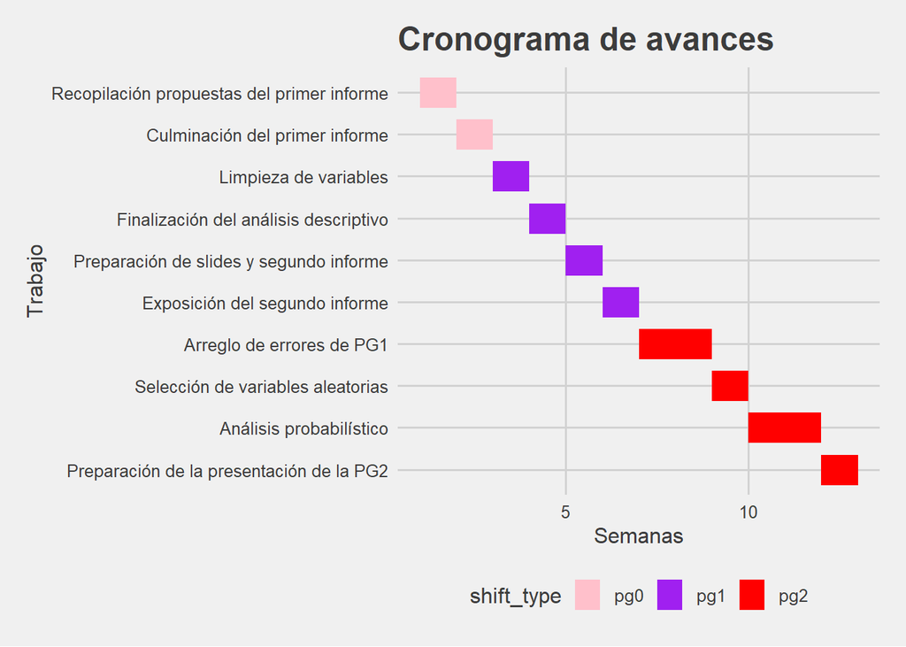

```r
ggplot(data2, aes(x=start, xend=end, y=name, yend=name, color=shift_type)) +
  theme_bw()+
  geom_segment(size=8) +
  labs(title='Cronograma de avances', x='Semanas', y='Trabajo') +
  scale_colour_manual(values = c('pink', 'purple','red')) +theme_fivethirtyeight() + theme(axis.title = element_text())
```

# Preguntas de investigación

1. ¿Qué variables determinan en mayor medida el puntaje que tiene cada hospedaje ?
2. ¿El precio de cada hospedaje se ve afectado por la cantidad de servicios brindados?
3. ¿Qué servicios fundamentales deben tener los hospedajes en París para captar la atención de las personas?

# Datos

## Recolección de datos

Obtuvimos nuestra base de datos de la página oficial de Airbnb, empresa que conecta hospedajes con huéspedes. Se optó por trabajar con una base de datos debido a que el enfoque de nuestro tema se basa en un estudio realizado en un país europeo. Por lo tanto, la distancia sería una limitante para obtener los datos mediante encuestas.

## Población, muestra y muestreo

### Población:

La población de nuestro estudio son todos los hospedajes en París.

### Muestra:

Nuestra muestra fue extraída de la base de datos de hospedajes de París, Francia brindada por Airbnb. Según lo requerido, estará conformada por 200 observaciones.

Puede encontrar la base de datos utilizada y muchas más de Airbnb en: http://insideairbnb.com/get-the-data/

### Muestreo:

Se utilizará el método de muestreo aleatorio simple: elegiremos al azar 200 observaciones y las guardaremos en un nuevo archivo csv, lo que permitirá mantener la aleatoriedad. Como se utiliza un método de muestreo probabilístico, la representatividad de la muestra es adecuada.

## Variables

### Variables numéricas:

| VARIABLE | TIPO | RESTRICCIÓN | DESCRIPCIÓN |
| --- | --- | --- | --- |
| longitude | Numérica Continua | Toma valores numéricos reales en grados sexagesimales | Utiliza el sistema geodésico mundial para la longitud |
| latitude | Numérica Continua | Toma valores numéricos reales en grados sexagesimales | Utiliza el sistema geodésico mundial para la latitud |
| bedrooms | Numérica Discreta | Toma valores numéricos enteros positivos | Número de dormitorios |
| beds | Numérica Discreta | Toma valores numéricos enteros positivos | Número de camas |
| number_of_review_ltm | Numérica Discreta | Toma valores numéricos enteros positivos | Cantidad de reviews en el último año |
| reviews_per_month | Numérica Continua | Toma valores numéricos positivos | Promedio de la cantidad de reviews que recibe un hospedaje al mes |
| price | Numérica Discreta | Toma valores numéricos positivos | Precio del alquiler del hospedaje en dólares |
| minimum_nights | Numérica Discreta | Toma valores numéricos enteros positivos | Noches mínimas indicadas por el dueño |
| maximum_nights | Numérica Discreta | Toma valores numéricos enteros positivos | Noches máximas indicadas por el dueño |
| number_of_reviews | Numérica Discreta | Toma valores numéricos enteros positivos | Cantidad de reseñas totales al hospedaje |
| bathrooms_text | Numérica Discreta | Toma un valor numérico positivo | Cantidad de baños |
| review_scores_value | Numérica discreta | Toma valores numéricos positivos en un rango de 0 a 5 | Promedio del puntaje asignado por los usuarios del hospedaje |
| review_scores_cleanliness | Numérica Discreta | Toma valores numéricos positivos en un rango de 0 a 5 | Promedio del puntaje asignado por los usuarios al hospedaje por la limpieza |
| review_scores_checkin | Numérica Discreta | Toma valores numéricos positivos en un rango de 0 a 5 | Promedio del puntaje asignado por los usuarios al hospedaje por el servicio en el CheckIn |
| review_scores_communication | Numérica Discreta | Toma valores numéricos positivos en un rango de 0 a 5 | Promedio del puntaje asignado por los usuarios al hospedaje por la atención al cliente |
| review_scores_location | Numérica Discreta | Toma valores numéricos positivos en un rango de 0 a 5 | Promedio del puntaje asignado por los usuarios al hospedaje por la localización |
| host_response_time | Numérica continua |  | Indica el tiempo que el dueño demora en responder medido en horas |

### Variables categóricas:

| VARIABLE | TIPO | RESTRICCIÓN | DESCRIPCIÓN |
| --- | --- | --- | --- |
| has_availability | Categórica Nominal | Esta representado por TRUE o FALSE | Informa si es que hay habitaciones desocupadas en el hospedaje |
| name | Categórica Nominal |  | Indica el nombre del hospedaje |
| neighbourhood | Categórica Nominal |  | Indica el nombre del vecindario |
| instant_bookable | Categórica Nominal | Esta representado por TRUE o FALSE | Indica si es que se puede reservar al instante. |
| room_type | Categórica Nominal |  | Indicando el tipo de cuarto que se ofrece como por ejemplo: privado, compartido, cuarto completo, etc. |
| property_type | Categórica Nominal |  | Indica el tipo de propiedad al que pertenece el hospedaje |
| wifi | Categórica Nominal | Esta representado por TRUE o FALSE | Informa si es que hay servicio de Wifi en el hospedaje |
| hot_water | Categórica Nominal | Esta representado por TRUE o FALSE | Informa si es que hay servicio de agua caliente en el hospedaje |
| host_has_profile_pic | Categórica Nominal | Esta representado por TRUE o FALSE | Informa si es que el dueño tiene una foto de perfil. |
| host_identity_verified | Categórica Nominal | Esta representado por TRUE o FALSE | Informa si es que el dueño ha verificado su identidad. |

## Limpieza de base de datos

```r
#Usado para hallar al azar 200 observaciones, no ejecutar nuevamente o cambiará todo el análisis.


#hallarFilas <- function(){
    #return (sample(1:56739,200)) #1er parámetro:  vector elementos de los que se escogerá al azar.
                        #2do parámetro: cantidad de elementos a escoger del vector
 # }

#filas <- hallarFilas() #Hallamos filas al azar. Esto lo debemos de comentar en la entrega y trabajar siempre con el DF2.csv que le salió a Yulinio

#DF <- DF[filas,]
#write_csv(DF,"DF2244")
```

### Recortando la cantidad de observaciones al azar (200 filas)

```r
DF <- read_csv("DF2244.csv")
```

Nos quedamos solo con las variables que utilizaremos

```r
DF <- select(DF,5,15,25,26,27,30,31,32,33,36,37,38,40,41,42,50,56,57,67,63,64,65,66,69,74)
```

### Adición de variables obtenidas de la data original

Existen datos importantes para el estudio que se encuentran dentro de una sola variable “Amenities”, las cuales toman valores de TRUE o FALSE. Para poder estudiarlas, debemos de copiarlas a mano a partir de las filas elegidas al azar de la base de datos original anteriormente.

#### Agregando la variable Wifi

```r
wifi<-c("TRUE","TRUE","TRUE","TRUE","TRUE","TRUE","TRUE","TRUE","TRUE","TRUE","TRUE","TRUE","TRUE","TRUE","TRUE", "FALSE", "TRUE", "TRUE", "TRUE", "TRUE", "TRUE", "TRUE", "TRUE", "TRUE", "TRUE", "TRUE","TRUE", "TRUE", "TRUE", "TRUE", "TRUE", "TRUE", "TRUE", "TRUE", "TRUE", "TRUE", "TRUE", "TRUE", "TRUE", "TRUE", "FALSE", "TRUE", "TRUE", "TRUE", "TRUE",  "TRUE", "TRUE", "TRUE", "TRUE",
        "TRUE", #50
        "TRUE", #51
        "TRUE", #52
        "TRUE", #53
        "TRUE", #54
        "FALSE", #55
        "TRUE", #56
        "TRUE", #57
        "TRUE", #58
        "TRUE", #59
        "TRUE", #60
        "TRUE", #61
        "TRUE", #62
        "TRUE", #63
        "TRUE", #64
        "TRUE", #65
        "TRUE", #66
        "TRUE", #67
        "TRUE", #68
        "TRUE", #69
        "TRUE", #70
        "TRUE", #71
        "TRUE", #72
        "TRUE", #73
        "TRUE", #74
        "TRUE", #75
        "TRUE", #76
        "TRUE", #77
        "TRUE", #78
        "TRUE", #79
        "TRUE", #80
        "TRUE", #81
        "TRUE", #82
        "TRUE", #83
        "TRUE", #84
        "TRUE", #85
        "FALSE", #86
        "TRUE", #87
        "TRUE", #88
        "TRUE", #89
        "TRUE", #90
        "TRUE", #91
        "TRUE", #92
        "TRUE", #93
        "TRUE", #94
        "TRUE", #95
        "TRUE", #96
        "TRUE", #97
        "TRUE", #98
        "TRUE", #99
        "TRUE", #100
        "TRUE", #101
        "TRUE", #102
        "TRUE", #103
        "TRUE", #104
        "TRUE", #105
        "TRUE", #106
        "TRUE", #107
        "TRUE", #108
        "TRUE", #109
        "TRUE", #110
        "TRUE", #111
        "TRUE", #112
        "TRUE", #113
        "TRUE", #114
        "TRUE", #115
        "TRUE", #116
        "TRUE", #117
        "TRUE", #118
        "TRUE", #119
        "TRUE", #120
        "TRUE", #121
        "TRUE", #122
        "TRUE", #123
        "TRUE", #124
        "FALSE", #125
        "TRUE", #126
        "TRUE", #127
        "TRUE", #128
        "TRUE", #129
        "TRUE", #130
        "TRUE", #131
        "TRUE", #132
        "FALSE", #133
        "TRUE", #134
        "TRUE", #135
        "TRUE", #136
        "TRUE", #137
        "TRUE", #138
        "TRUE", #139
        "FALSE", #140
        "TRUE", #141
        "TRUE", #142
        "TRUE", #143
        "TRUE", #144
        "TRUE", #145
        "TRUE", #146
        "TRUE", #147
        "TRUE", #148
        "TRUE", #149
        "TRUE", #150
        "TRUE", #151
        "TRUE", #152
        "TRUE", #153
        "TRUE", #154
        "TRUE", #155
        "TRUE", #156
        "TRUE", #157
        "FALSE", #158
        "TRUE", #159
        "TRUE", #160
        "TRUE", #161
        "TRUE", #162
        "TRUE", #163
        "TRUE", #164
        "TRUE", #165
        "TRUE", #166
        "TRUE", #167
        "TRUE", #168
        "TRUE", #169
        "TRUE", #170
        "TRUE", #171
        "TRUE", #172
        "TRUE", #173
        "TRUE", #174
        "TRUE", #175
        "TRUE", #176
        "TRUE", #177
        "TRUE", #178
        "TRUE", #179
        "TRUE", #180
        "TRUE", #181
        "TRUE", #182
        "TRUE", #183
        "TRUE", #184
        "TRUE", #185
        "TRUE", #186
        "TRUE", #187
        "TRUE", #188
        "TRUE", #189
        "TRUE", #190
        "TRUE", #191
        "TRUE", #192
        "TRUE", #193
        "TRUE", #194
        "TRUE", #195
        "TRUE", #196
        "TRUE", #197
        "TRUE", #198
        "TRUE", #199
        "TRUE") #200
DF$wifi<-wifi
```

#### Agregando la variable Hot_water

```r
hot_water<-c("TRUE",#1
             "FALSE",#2
             "TRUE",#3
             "TRUE",#4
             "TRUE",#5
             "TRUE",#6
             "TRUE",#7
             "TRUE",#8
             "TRUE",#9
             "TRUE",#10
             "TRUE",#11
             "TRUE",#12
             "TRUE",#13
             "FALSE",#14
             "TRUE",#15
             "TRUE",#16
             "TRUE",#17
             "TRUE",#18
             "TRUE",#19
             "FALSE",#20
             "TRUE",#21
             "FALSE",#22
             "TRUE",#23
             "FALSE",#24
             "FALSE",#25
             "TRUE",#26
             "TRUE",#27
             "TRUE",#28
             "FALSE",#29
             "FALSE",#30
             "TRUE",#31
             "FALSE",#32
             "FALSE",#33
             "FALSE",#34
             "FALSE",#35
             "FALSE",#36
             "TRUE",#37
             "TRUE",#38
             "TRUE",#39
             "TRUE",#40
             "TRUE",#41
             "TRUE",#42
             "TRUE",#43
             "TRUE",#44
             "TRUE",#45
             "TRUE",#46
             "TRUE",#47
             "TRUE",#48
             "TRUE",#49
             "FALSE",#50
             "FALSE",#51
             "TRUE",#52
             "FALSE",#53
             "TRUE",#54
             "FALSE",#55
             "TRUE",#56
             "FALSE",#57
             "TRUE",#58
             "FALSE",#59
             "TRUE",#60
             "FALSE",#61
             "TRUE",#62
             "FALSE",#63
             "FALSE",#64
             "TRUE",#65
             "FALSE",#66
             "FALSE",#67
             "FALSE",#68
             "FALSE",#69
             "TRUE",#70
             "TRUE",#71
             "FALSE",#72
             "TRUE",#73
             "TRUE",#74
             "TRUE",#75
             "TRUE",#76
             "FALSE",#77
             "TRUE",#78
             "TRUE",#79
             "FALSE",#80
             "TRUE",#81
             "TRUE",#82
             "TRUE",#83
             "TRUE",#84
             "FALSE",#85
             "TRUE",#86
             "TRUE",#87
             "TRUE",#88
             "FALSE",#89
             "TRUE",#90
             "TRUE",#91
             "TRUE",#92
             "FALSE",#93
             "TRUE",#94
             "TRUE",#95
             "TRUE",#96
             "FALSE",#97
             "FALSE",#98
             "TRUE",#99
             "FALSE",#100
             "TRUE",#101
             "FALSE",#102
             "FALSE",#103
             "FALSE",#104
             "TRUE",#105
             "TRUE",#106
             "TRUE",#107
             "TRUE",#108
             "TRUE",#109
             "TRUE",#110
             "TRUE",#111
             "TRUE",#112
             "TRUE",#113
             "FALSE",#114
             "FALSE",#115
             "TRUE",#116
             "TRUE",#117
             "FALSE",#118
             "FALSE",#119
             "FALSE",#120
             "FALSE",#121
             "FALSE",#122
             "FALSE",#123
             "TRUE",#124
             "TRUE",#125
             "TRUE",#126
             "TRUE",#127
             "TRUE",#128
             "TRUE",#129
             "TRUE",#130
             "TRUE",#131
             "TRUE",#132
             "FALSE",#133
             "TRUE",#134
             "TRUE",#135
             "FALSE",#136
             "TRUE",#137
             "FALSE",#138
             "FALSE",#139
             "FALSE",#140
             "TRUE",#141
             "TRUE",#142
             "FALSE",#143
             "TRUE",#144
             "TRUE",#145
             "FALSE",#146
             "TRUE",#147
             "FALSE",#148
             "TRUE",#149
             "FALSE",#150
             "TRUE",#151
             "TRUE",#152
             "TRUE",#153
             "TRUE",#154
             "TRUE",#155
             "FALSE",#156
             "TRUE",#157
             "TRUE",#158
             "FALSE",#159
             "TRUE",#160
             "TRUE",#161
             "TRUE",#162
             "TRUE",#163
             "TRUE",#164
             "TRUE",#165
             "TRUE",#166
             "FALSE",#167
             "TRUE",#168
             "FALSE",#169
             "TRUE",#170
             "TRUE",#171
             "FALSE",#172
             "FALSE",#173
             "FALSE",#174
             "TRUE",#175
             "TRUE",#176
             "TRUE",#177
             "TRUE",#178
             "TRUE",#179
             "FALSE",#180
             "TRUE",#181
             "TRUE",#182
             "FALSE",#183
             "TRUE",#184
             "TRUE",#185
             "TRUE",#186
             "TRUE",#187
             "TRUE",#188
             "TRUE",#189
             "TRUE",#190
             "TRUE",#191
             "FALSE",#192
             "FALSE",#193
             "TRUE",#194
             "TRUE",#195
             "TRUE",#196
             "TRUE",#197
             "TRUE",#198
             "FALSE",#199
             "TRUE")#200
DF$hot_water<- hot_water
```

### Resumen de las variables

```r
summary(DF)
```

```
##      name           host_response_time host_has_profile_pic
##  Length:200         Length:200         Mode :logical
##  Class :character   Class :character   FALSE:4
##  Mode  :character   Mode  :character   TRUE :196
##
##
##
##
##  host_identity_verified neighbourhood         latitude       longitude
##  Mode :logical          Length:200         Min.   :48.81   Min.   :2.231
##  FALSE:28               Class :character   1st Qu.:48.85   1st Qu.:2.323
##  TRUE :172              Mode  :character   Median :48.86   Median :2.350
##                                            Mean   :48.86   Mean   :2.346
##                                            3rd Qu.:48.88   3rd Qu.:2.374
##                                            Max.   :48.91   Max.   :2.467
##
##  property_type       room_type         bathrooms_text        bedrooms
##  Length:200         Length:200         Length:200         Min.   :1.000
##  Class :character   Class :character   Class :character   1st Qu.:1.000
##  Mode  :character   Mode  :character   Mode  :character   Median :1.000
##                                                           Mean   :1.302
##                                                           3rd Qu.:1.000
##                                                           Max.   :4.000
##                                                           NA's   :31
##       beds          price           minimum_nights   maximum_nights
##  Min.   :1.000   Length:200         Min.   :  1.00   Min.   :   6
##  1st Qu.:1.000   Class :character   1st Qu.:  2.00   1st Qu.: 365
##  Median :1.000   Mode  :character   Median :  4.00   Median :1125
##  Mean   :1.672                      Mean   : 95.17   Mean   : 759
##  3rd Qu.:2.000                      3rd Qu.: 90.25   3rd Qu.:1125
##  Max.   :6.000                      Max.   :365.00   Max.   :1125
##  NA's   :2
##  has_availability number_of_reviews number_of_reviews_ltm review_scores_value
##  Mode:logical     Min.   :  0.00    Min.   : 0.000        Min.   :3.000
##  TRUE:200         1st Qu.:  1.00    1st Qu.: 0.000        1st Qu.:4.500
##                   Median :  5.50    Median : 0.000        Median :4.725
##                   Mean   : 22.48    Mean   : 5.935        Mean   :4.630
##                   3rd Qu.: 28.00    3rd Qu.: 5.250        3rd Qu.:4.880
##                   Max.   :239.00    Max.   :59.000        Max.   :5.000
##                                                           NA's   :50
```

[output cut: 9 more lines]

```
##  Min.   :4.000          Mode :logical    Min.   :0.0100    Length:200
##  1st Qu.:4.803          FALSE:135        1st Qu.:0.1625    Class :character
##  Median :4.930          TRUE :65         Median :0.5150    Mode  :character
##  Mean   :4.843                           Mean   :0.9691
##  3rd Qu.:5.000                           3rd Qu.:1.2750
##  Max.   :5.000                           Max.   :6.7700
##  NA's   :50                              NA's   :46
##   hot_water
##  Length:200
##  Class :character
##  Mode  :character
##
##
##
##
```

### Análisis de dormitorios

```r
DF %>% count(bedrooms)
```

| bedrooms | n |
| --- | --- |
| 1 | 132 |
| 2 | 26 |
| 3 | 8 |
| 4 | 3 |
| NA | 31 |

Todos son datos numéricos, parece limpia.

### Análisis de camas

```r
DF %>% count(beds)
```

| beds | n |
| --- | --- |
| 1 | 108 |
| 2 | 62 |
| 3 | 17 |
| 4 | 8 |
| 5 | 2 |
| 6 | 1 |
| NA | 2 |

Todos son datos numéricos, parece limpio.

### Análisis de la cantidad de reviews por mes (promedio)

```r
DF %>% count(reviews_per_month)
```

| reviews_per_month | n |
| --- | --- |
| 0.01 | 3 |
| 0.02 | 4 |
| 0.03 | 3 |
| 0.04 | 3 |
| 0.05 | 2 |
| 0.06 | 2 |
| 0.07 | 3 |
| 0.08 | 2 |
| 0.09 | 1 |
| 0.10 | 4 |

[output cut: 93 more lines]

Todas son respuestas numéricas y decimales, lo que indica que las cifras se hallaron de una media. La variable está limpia.

### Análisis del precio

```r
DF %>% count(price)
```

| price | n |
| --- | --- |
| $1,370.00 | 1 |
| $100.00 | 7 |
| $102.00 | 1 |
| $104.00 | 1 |
| $106.00 | 3 |
| $109.00 | 1 |
| $110.00 | 2 |
| $111.00 | 1 |
| $114.00 | 1 |
| $115.00 | 2 |

[output cut: 91 more lines]

Todos los precios siguen un mismo formato (con $ antes del número), pero sería mejor utilizarla como dato numérico.

La convertimos a numérico:

```r
DF$price[DF$price == "$1,005.00"] <- 1005
DF$price[DF$price == "$1,700.00"] <- 1700
DF$price[DF$price == "$100.00"] <- 100
DF$price[DF$price == "$102.00"] <- 102
DF$price[DF$price == "$103.00"] <- 103
DF$price[DF$price == "$105.00"] <- 105
DF$price[DF$price == "$106.00"] <- 106
DF$price[DF$price == "$108.00"] <- 108
DF$price[DF$price == "$109.00"] <- 109
DF$price[DF$price == "$110.00"] <- 110
DF$price[DF$price == "$112.00"] <- 112
DF$price[DF$price == "$113.00"] <- 113
DF$price[DF$price == "$115.00"] <- 115
DF$price[DF$price == "$118.00"] <- 118
DF$price[DF$price == "$113.00"] <- 113
DF$price[DF$price == "$115.00"] <- 115
DF$price[DF$price == "$118.00"] <- 118
DF$price[DF$price == "$119.00"] <- 119
DF$price[DF$price == "$120.00"] <- 120
DF$price[DF$price == "$125.00"] <- 125
DF$price[DF$price == "$127.00"] <- 127
DF$price[DF$price == "$129.00"] <- 129
DF$price[DF$price == "$130.00"] <- 113
DF$price[DF$price == "$133.00"] <- 133
DF$price[DF$price == "$135.00"] <- 135
DF$price[DF$price == "$137.00"] <- 137
DF$price[DF$price == "$140.00"] <- 140
DF$price[DF$price == "$143.00"] <- 143
DF$price[DF$price == "$146.00"] <- 146
DF$price[DF$price == "$150.00"] <- 150
DF$price[DF$price == "$151.00"] <- 151
DF$price[DF$price == "$154.00"] <- 154
DF$price[DF$price == "$156.00"] <- 156
DF$price[DF$price == "$170.00"] <- 170
DF$price[DF$price == "$173.00"] <- 173
DF$price[DF$price == "$18.00"] <- 18
DF$price[DF$price == "$180.00"] <- 180
DF$price[DF$price == "$182.00"] <- 182
DF$price[DF$price == "$186.00"] <- 186
DF$price[DF$price == "$190.00"] <- 190
DF$price[DF$price == "$2,400.00"] <- 2400
DF$price[DF$price == "$20.00"] <- 20
DF$price[DF$price == "$200.00"] <- 200
DF$price[DF$price == "$210.00"] <- 210
DF$price[DF$price == "$22.00"] <- 22
DF$price[DF$price == "$236.00"] <- 236
DF$price[DF$price == "$25.00"] <- 25
DF$price[DF$price == "$250.00"] <- 250
DF$price[DF$price == "$264.00"] <- 254
DF$price[DF$price == "$267.00"] <- 267
DF$price[DF$price == "$27.00"] <- 27
DF$price[DF$price == "$30.00"] <- 30
DF$price[DF$price == "$33.00"] <- 33
DF$price[DF$price == "$34.00"] <- 34
DF$price[DF$price == "$35.00"] <- 35
DF$price[DF$price == "$38.00"] <- 38
DF$price[DF$price == "$40.00"] <- 40
DF$price[DF$price == "$42.00"] <- 42
DF$price[DF$price == "$43.00"] <- 43
DF$price[DF$price == "$44.00"] <- 44
DF$price[DF$price == "$443.00"] <- 443
DF$price[DF$price == "$45.00"] <- 45
DF$price[DF$price == "$450.00"] <- 450
DF$price[DF$price == "$47.00"] <- 47
DF$price[DF$price == "$48.00"] <- 48
DF$price[DF$price == "$49.00"] <- 49
DF$price[DF$price == "$5,000.00"] <- 5000
DF$price[DF$price == "$50.00"] <- 50
DF$price[DF$price == "$500.00"] <- 500
DF$price[DF$price == "$51.00"] <- 51
DF$price[DF$price == "$510.00"] <- 510
DF$price[DF$price == "$53.00"] <- 53
DF$price[DF$price == "$54.00"] <- 54
DF$price[DF$price == "$55.00"] <- 55
DF$price[DF$price == "$56.00"] <- 56
DF$price[DF$price == "$57.00"] <- 57
DF$price[DF$price == "$59.00"] <- 59
DF$price[DF$price == "$60.00"] <- 60
DF$price[DF$price == "$61.00"] <- 61
DF$price[DF$price == "$62.00"] <- 62
DF$price[DF$price == "$63.00"] <- 63
DF$price[DF$price == "$64.00"] <- 64
DF$price[DF$price == "$65.00"] <- 65
DF$price[DF$price == "$66.00"] <- 66
DF$price[DF$price == "$67.00"] <- 67
DF$price[DF$price == "$68.00"] <- 68
DF$price[DF$price == "$69.00"] <- 69
DF$price[DF$price == "$697.00"] <- 697
DF$price[DF$price == "$70.00"] <- 70
DF$price[DF$price == "$71.00"] <- 71
DF$price[DF$price == "$73.00"] <- 73
DF$price[DF$price == "$75.00"] <- 75
DF$price[DF$price == "$76.00"] <- 76
DF$price[DF$price == "$77.00"] <- 77
DF$price[DF$price == "$79.00"] <- 79
DF$price[DF$price == "$80.00"] <- 80
DF$price[DF$price == "$81.00"] <- 81
DF$price[DF$price == "$83.00"] <- 83
DF$price[DF$price == "$85.00"] <- 85
DF$price[DF$price == "$89.00"] <- 89
DF$price[DF$price == "$90.00"] <- 90
DF$price[DF$price == "$91.00"] <- 91
DF$price[DF$price == "$92.00"] <- 92
DF$price[DF$price == "$94.00"] <- 94
DF$price[DF$price == "$95.00"] <- 95
DF$price[DF$price == "$97.00"] <- 97
DF$price[DF$price == "$99.00"] <- 99
```

Analizo si se ha eliminado el signo dolar, puntos y comas

```r
DF %>% count(price)
```

| price | n |
| --- | --- |
| $1,370.00 | 1 |
| $104.00 | 1 |
| $111.00 | 1 |
| $114.00 | 1 |
| $121.00 | 1 |
| $139.00 | 1 |
| $148.00 | 2 |
| $155.00 | 1 |
| $157.00 | 1 |
| $158.00 | 1 |

[output cut: 91 more lines]

La convierto a numérica

```r
DF$price <- strtoi(DF$price)
```

Comprobamos que sea numérica

```r
DF %>% count(price)
```

| price | n |
| --- | --- |
| 35 | 1 |
| 38 | 1 |
| 40 | 6 |
| 44 | 2 |
| 45 | 9 |
| 47 | 1 |
| 50 | 5 |
| 51 | 1 |
| 53 | 1 |
| 54 | 1 |

[output cut: 39 more lines]

### Análisis de la cantidad de baños

```r
DF %>% count(bathrooms_text)
```

| bathrooms_text | n |
| --- | --- |
| 0 baths | 2 |
| 1 bath | 154 |
| 1 private bath | 13 |
| 1 shared bath | 10 |
| 1.5 baths | 8 |
| 2 baths | 9 |
| 2 shared baths | 1 |
| 3 baths | 2 |
| NA | 1 |

Debemos quitar texto convertirla a numérica

```r
DF$bathrooms_text[DF$bathrooms_text == "0 baths"] <- 0
DF$bathrooms_text[DF$bathrooms_text == "1 bath"] <- 1
DF$bathrooms_text[DF$bathrooms_text == "1 private bath"] <- 1
DF$bathrooms_text[DF$bathrooms_text == "1 shared bath"] <- 1
DF$bathrooms_text[DF$bathrooms_text == "1.5 shared baths" | DF$bathrooms_text == "1.5 baths"] <- 1
DF$bathrooms_text[DF$bathrooms_text %in% c("2 baths", "2.5 baths")] <- 2
DF$bathrooms_text[DF$bathrooms_text %in% c("3 baths", "3 shared baths")] <- 3
DF$bathrooms_text[DF$bathrooms_text == "4 baths"] <- 4
DF$bathrooms_text[DF$bathrooms_text %in% c("Half-bath","Shared half-bath")] <- 1
```

Revisamos que se haya limpiado

```r
DF %>% count(bathrooms_text)
```

| bathrooms_text | n |
| --- | --- |
| 0 | 2 |
| 1 | 185 |
| 2 | 9 |
| 2 shared baths | 1 |
| 3 | 2 |
| NA | 1 |

La convertimos a variable numérica

```r
DF$bathrooms_text <- strtoi(DF$bathrooms_text)
```

```r
DF %>% count(bathrooms_text)
```

| bathrooms_text | n |
| --- | --- |
| 0 | 2 |
| 1 | 185 |
| 2 | 9 |
| 3 | 2 |
| NA | 2 |

Ahora la variable es numérica. Está limpia.

### Análisis del tiempo de respuesta del dueño

```r
DF %>% count(host_response_time)
```

| host_response_time | n |
| --- | --- |
| N/A | 89 |
| a few days or more | 1 |
| within a day | 22 |
| within a few hours | 28 |
| within an hour | 60 |

Esta variable permitirá saber si es que el tiempo en que demora en responder el dueño afecta en la elección o puntaje de los hospedajes. Para ello, la convertimos a categórica ordinal:

```r
DF$host_response_time <- factor(DF$host_response_time, levels = c(NA,"within an hour", "within a few hours", "within a day","a few days or more"))
```

```r
DF %>% count(host_response_time)
```

| host_response_time | n |
| --- | --- |
| within an hour | 60 |
| within a few hours | 28 |
| within a day | 22 |
| a few days or more | 1 |
| NA | 89 |

# Análisis descriptivo

## host_response_time

```r
DF %>% count(host_response_time)
```

| host_response_time | n |
| --- | --- |
| within an hour | 60 |
| within a few hours | 28 |
| within a day | 22 |
| a few days or more | 1 |
| NA | 89 |

Es una variable categóricas, entonces solo podemos hallar la moda.

### Moda

```r
table(DF$host_response_time)[table(DF$host_response_time) == max(table(DF$host_response_time))]
```

```
## within an hour
##             60
```

```r
# La mayoria de los dueños responde en within an hour
```

La mayoría de los dueños responde en 1 hora aprox.

### Gráfica de barras

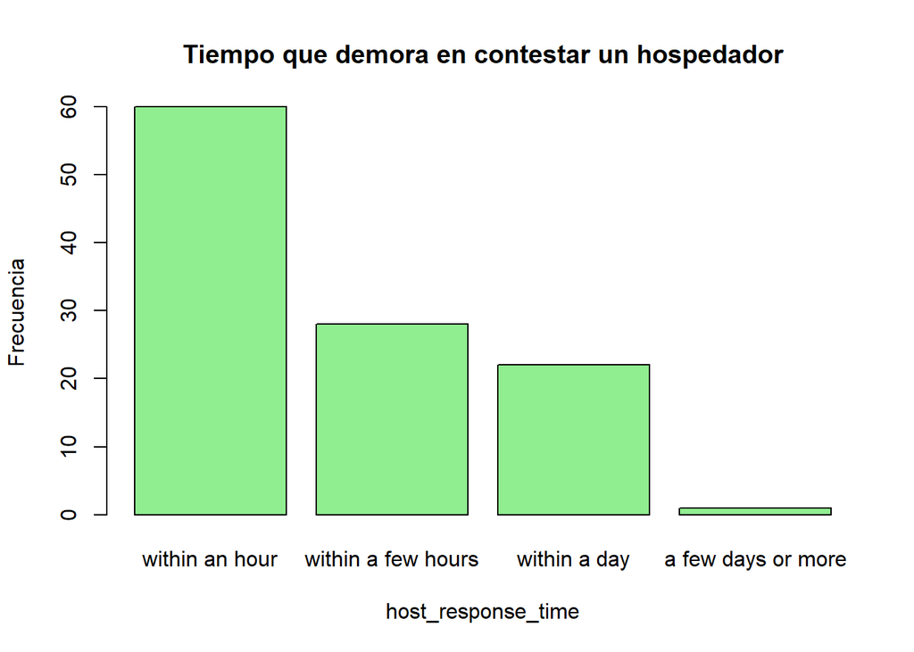

```r
x <- table(DF$host_response_time)
barplot(x,xlab = "host_response_time",ylab = "Frecuencia",main = "Tiempo que demora en contestar un hospedador",col = "light green")
```

El gráfico confirma el resultado obtenido de la moda.

## host_has_porfile

```r
DF %>% count(host_has_profile_pic)
```

| host_has_profile_pic | n |
| --- | --- |
| FALSE | 4 |
| TRUE | 196 |

### Moda

```r
table(DF$host_has_profile_pic)[table(DF$host_has_profile_pic) == max(table(DF$host_has_profile_pic))]
```

```
## TRUE
##  196
```

La mayoría de los dueños cuenta con foto de perfil.

### Gráfico de barras

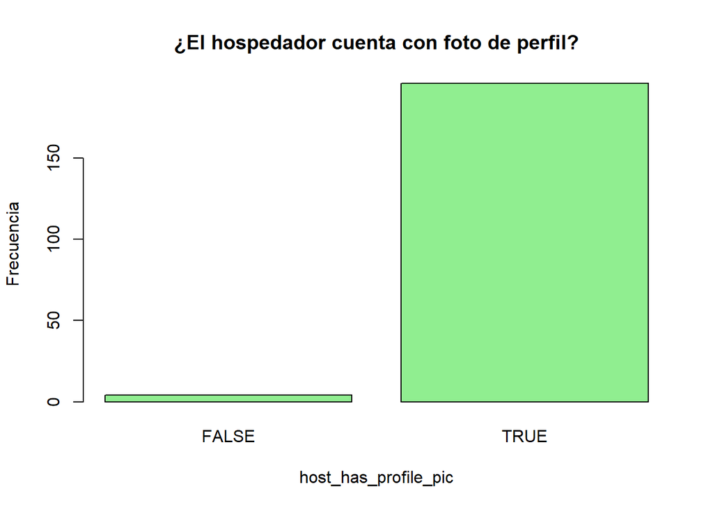

```r
x <- table(DF$host_has_profile_pic)
barplot(x,xlab = "host_has_profile_pic",ylab = "Frecuencia",main = "¿El hospedador cuenta con foto de perfil?",col = "light green")
```

Podemos interpretar del gráfico que la mayoría de las personas posee una foto de perfil.

## host_identity_verified

```r
DF %>% count(host_identity_verified)
```

| host_identity_verified | n |
| --- | --- |
| FALSE | 28 |
| TRUE | 172 |

### Moda

```r
table(DF$host_identity_verified)[table(DF$host_identity_verified) == max(table(DF$host_identity_verified))]
```

```
## TRUE
##  172
```

La mayoría de los dueños tiene identidad verificada.

### Gráfico de barras

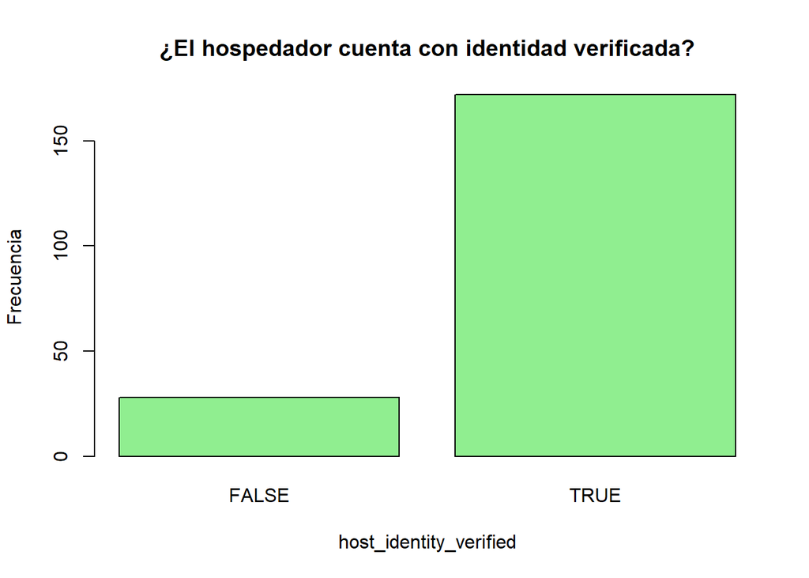

```r
x <- table(DF$host_identity_verified)
barplot(x,xlab = "host_identity_verified",ylab = "Frecuencia",main = "¿El hospedador cuenta con identidad verificada?",col = "light green")
```

Interpretando la gráfica podemos concluir que la mayoría de las personas tienen identidad verificada.

## Descriptores de property_type

```r
table(DF$property_type)
```

```
##
##                      Entire condo                       Entire home
##                                 8                                 2
##                       Entire loft                Entire rental unit
##                                 1                               160
##         Entire serviced apartment                  Entire townhouse
##                                 1                                 1
## Private room in bed and breakfast   Private room in casa particular
##                                 1                                 1
##             Private room in condo        Private room in guesthouse
##                                 1                                 1
##       Private room in rental unit         Room in bed and breakfast
##                                11                                 1
##            Room in boutique hotel                     Room in hotel
##                                 8                                 3
```

Es una variable categórica con muchos datos. Entonces solo podemos hallar la moda (R no puede representar tantos datos en un gráfico).

### Moda

```r
table(DF$property_type)[table(DF$property_type)==max(table(DF$property_type))]
```

```
## Entire rental unit
##                160
```

La propiedad más común es de tipo Entire rental unit.

## Descriptores de room_type

```r
table(DF$room_type)
```

```
##
## Entire home/apt      Hotel room    Private room
##             173               6              21
```

Es una variable categórica. Entonces, solo podemos hallar la moda.

### Descriptores gráficos

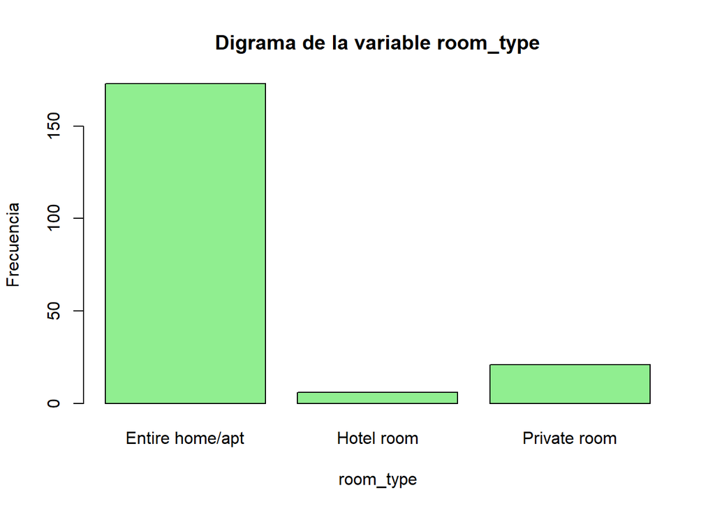

```r
x <- table(DF$room_type)
barplot(x,xlab = "room_type",ylab = "Frecuencia",main = "Digrama de la variable room_type",col = "light green")
```

Se observa que hay más habitaciones del tipo Entire home/apt y muy pocas del tipo Hotel room. #### Moda

```r
table(DF$room_type)[table(DF$room_type)==max(table(DF$room_type))]
```

```
## Entire home/apt
##             173
```

Los tipos de viviendas más ofrecidas son casas o apartamentos completos.

### Descriptores de bathrooms_text

```r
table(DF$bathrooms_text)
```

```
##
##   0   1   2   3
##   2 185   9   2
```

Es una variable numérica, entonces podemos hallar sus descriptores numéricos.

#### Descriptores gráficos

##### Boxplot

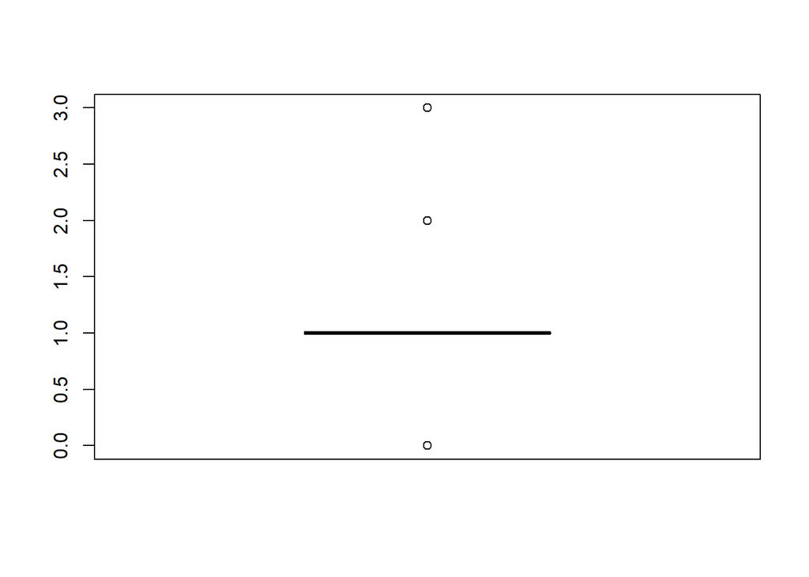

```r
#Grafica de bigotes, para identificar los datos atipicos
boxplot(DF$bathrooms_text)
```

Análisis:

- El 50% de los datos ronda por el valor de 1.
- El resto de cantidades de baños son considerados datos atípicos.

##### Gráfica de puntos

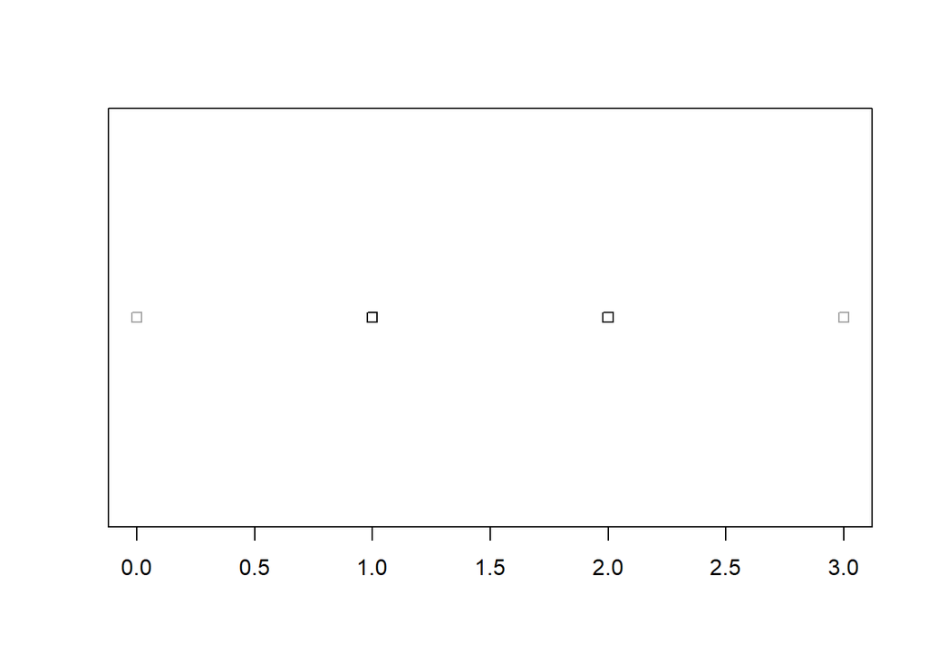

```r
#Grafica de puntos en linea recta, se usa para identificar  datos atípicos
stripchart(DF$bathrooms_text,col=rgb(0,0,0,0.2))
```

Podemos observar de una mejor manera los datos atípicos. ##### Histograma

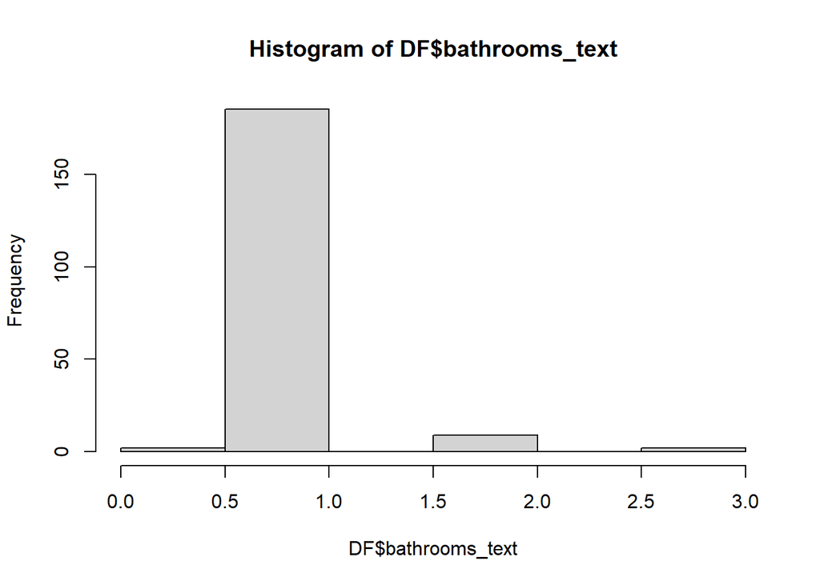

```r
#Histograma
hist(DF$bathrooms_text)
```

La mayor cantidad de baños se encuentran entre 0.5 y 1.

### Media

```r
mean(DF$bathrooms_text,na.rm=TRUE)
```

```
## [1] 1.055556
```

Podemos afirmar que poseen en promedio un baño. ### Mediana

```r
median(DF$bathrooms_text,na.rm=TRUE)
```

```
## [1] 1
```

### Moda

```r
table(DF$bathrooms_text)[table(DF$bathrooms_text)==max(table(DF$bathrooms_text))]
```

```
##   1
## 185
```

La única moda es 1. La mayoría de hospedajes cuenta con un solo baño.

### Cuantiles

```r
cuantiles <- quantile(DF$bathrooms_text, type=2,na.rm=TRUE)
cuantiles
```

```
##   0%  25%  50%  75% 100%
##    0    1    1    1    3
```

Análisis: El 100% de los hospedajes tienes 3 o menos baños. Por otro lado, el 75% de los baños tienen 1 o menos baños.

### Rango

```r
rango <- max(DF$bathrooms_text,na.rm=TRUE) - min(DF$bathrooms_text,na.rm=TRUE)
rango
```

```
## [1] 3
```

La distancia entre el máximo y mínimo valor es 3.

### Rango intercuartil

```r
IQR(DF$bathrooms_text,na.rm=TRUE)
```

```
## [1] 0
```

Análisis: El 50% de los datos son el mismo valor, pues el rango intercuartil es 0.

### Desviación estándar

```r
dv <- sd(DF$bathrooms_text,na.rm=TRUE)
dv
```

```
## [1] 0.3055235
```

Los datos están muy juntos, pues la desviación estándar es muy pequeña.

### Varianza

```r
varianza <- dv^2
varianza
```

```
## [1] 0.09334461
```

Nos indica que hay una medida de dispersión del 0.09 aprox. en torno a la media. ### Coeficiente de variación

```r
cv <- function(x){
  return(sd(x, na.rm= TRUE)/mean(x, na.rm = TRUE))
}

cv(DF$bathrooms_text)
```

```
## [1] 0.2894433
```

Los datos no están muy dispersos de la media.

## Bedrooms

```r
table(DF$bedrooms)
```

```
##
##   1   2   3   4
## 132  26   8   3
```

Es una variable numérica, entonces podemos hallar sus descriptores numéricos.

### Descriptores gráficos

#### Boxplot

[figure not shown]

```r
boxplot(DF$bathrooms_text)
```

Análisis:

#### De puntos

[figure not shown]

```r
#Grafica de puntos en linea recta, se usa para identficar  datos atipicos
stripchart(DF$bathrooms_text,col=rgb(0,0,0,0.2))
```

[figure not shown]

```r
#Histograma
hist(DF$bathrooms_text)
```

Nuevamente, se puede apreciar que la mayoría de hospedajes cuentan con solamente 1 baño.

### Media

```r
mean(DF$bedrooms,na.rm=TRUE)
```

```
## [1] 1.301775
```

En promedio poseen un dormitorio. ### Mediana

```r
median(DF$bedrooms,na.rm=TRUE)
```

```
## [1] 1
```

### Moda

```r
table(DF$bedrooms)[table(DF$bedrooms)==max(table(DF$bedrooms))]
```

```
##   1
## 132
```

La única moda es 1, se puede concluir que existen muchos hospedajes de un solo dormitorio.

### Cuantiles

```r
cuantiles <- quantile(DF$bedrooms, type=2,na.rm=TRUE)
cuantiles
```

```
##   0%  25%  50%  75% 100%
##    1    1    1    1    4
```

El 75% de los hospedajes tiene 1 o menos habitaciones. El 100% de los hospedajes tiene 4 o menos habitaciones.

### Rango

```r
rango <- max(DF$bedrooms,na.rm=TRUE) - min(DF$bedrooms,na.rm=TRUE)
rango
```

```
## [1] 3
```

Los datos en general no están muy dispersos.

### Rango intercuartil

```r
IQR(DF$bedrooms,na.rm=TRUE)
```

```
## [1] 0
```

El 50% de los datos son el mismo valor.

### Desviación estandar

```r
dv <- sd(DF$bedrooms,na.rm=TRUE)
dv
```

```
## [1] 0.6436941
```

Los datos no parecen dispersos.

### Varianza

```r
varianza <- dv^2
varianza
```

```
## [1] 0.4143421
```

### Coeficiente de variación

```r
cv <- function(x){
  return(sd(x, na.rm= TRUE)/mean(x, na.rm = TRUE))
}

cv(DF$bedrooms)
```

```
## [1] 0.4944741
```

Los datos no parecen muy dispersos de la media.

## Beds

```r
table(DF$beds)
```

```
##
##   1   2   3   4   5   6
## 108  62  17   8   2   1
```

Es variable numérica, hallo sus descriptores numéricos.

### Descriptores gráficos

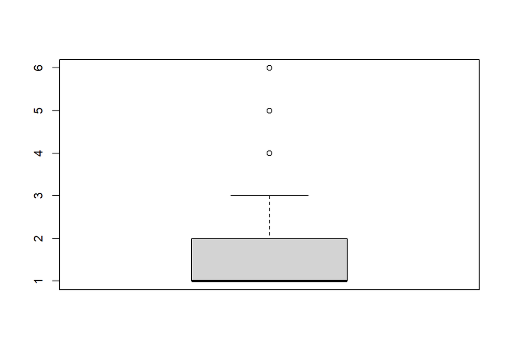

```r
#Grafica de bigotes, para identificar los datos atipicos
boxplot(DF$beds)
```

Análisis:

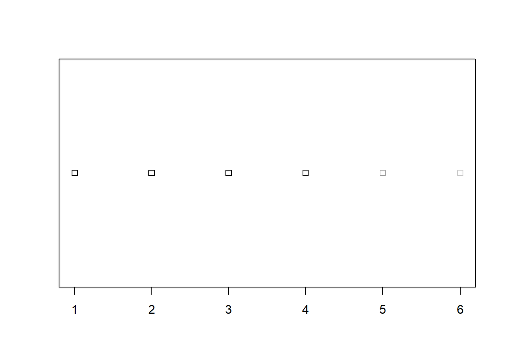

```r
#Grafica de puntos en linea recta, se usa para identficar  datos atipicos
stripchart(DF$beds,col=rgb(0,0,0,0.2))
```

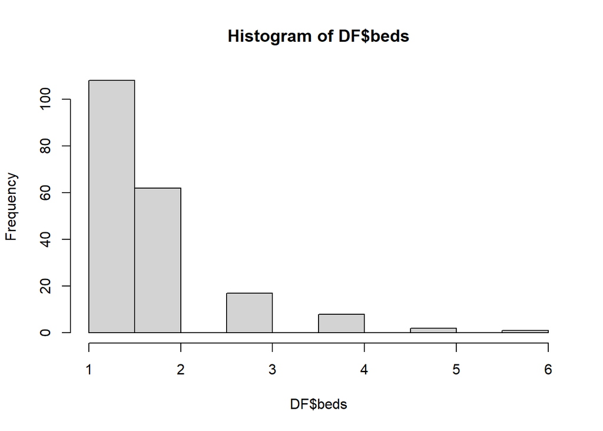

```r
#Histograma
hist(DF$beds)
```

Los hospedajes tienen en su mayoría 1 cama. Le siguen los hospedajes con 2 camas y luego los que tienen 3.

### Media

```r
mean(DF$beds,na.rm=TRUE)
```

```
## [1] 1.671717
```

La mayoría de los hospedajes poseen un cama. ### Mediana

```r
median(DF$beds,na.rm=TRUE)
```

```
## [1] 1
```

### Moda

```r
table(DF$beds)[table(DF$beds)==max(table(DF$beds))]
```

```
##   1
## 108
```

La única moda es 1.Quiere decir que hay más hospedajes de 1 cama.

### Cuantiles

```r
cuantiles <- quantile(DF$beds, type=2,na.rm=TRUE)
cuantiles
```

```
##   0%  25%  50%  75% 100%
##    1    1    1    2    6
```

El 75% tiene 2 o menos camas. El 100% tiene 6 o menos camas.

### Rango

```r
rango <- max(DF$beds,na.rm=TRUE) - min(DF$beds,na.rm=TRUE)
rango
```

```
## [1] 5
```

### Rango intercuartil

```r
IQR(DF$beds,na.rm=TRUE)
```

```
## [1] 1
```

El 50% de los datos varían en 1, es decir toman 2 valores enteros a lo mucho.

### Desviación estandar

```r
dv <- sd(DF$beds,na.rm=TRUE)
dv
```

```
## [1] 0.9280229
```

La dispersión de los datos existe. Sin embargo, en el contexto de camas podría considerarse significante.

### Varianza

```r
varianza <- dv^2
varianza
```

```
## [1] 0.8612265
```

### Coeficiente de variación

```r
cv <- function(x){
  return(sd(x, na.rm= TRUE)/mean(x, na.rm = TRUE))
}

cv(DF$beds)
```

```
## [1] 0.5551315
```

Los datos varían regular respecto a la media.

## Price

```r
table(DF$price)
```

```
##
##  35  38  40  44  45  47  50  51  53  54  55  56  60  63  64  65  70  71  73  75
##   1   1   6   2   9   1   5   1   1   1   4   1  10   2   1   4   9   1   1   5
##  76  80  83  85  89  90  92  95  99 100 102 106 109 110 115 119 120 127 135 150
##   1  10   1   5   1   4   1   1   1   7   1   3   1   2   2   1   6   1   3   7
## 151 154 156 170 180 200 250 450
##   1   1   1   1   2   3   4   2
```

Es numérica, podemos hallar sus descriptores numéricos.

### Descriptores gráficos

#### De boxplot

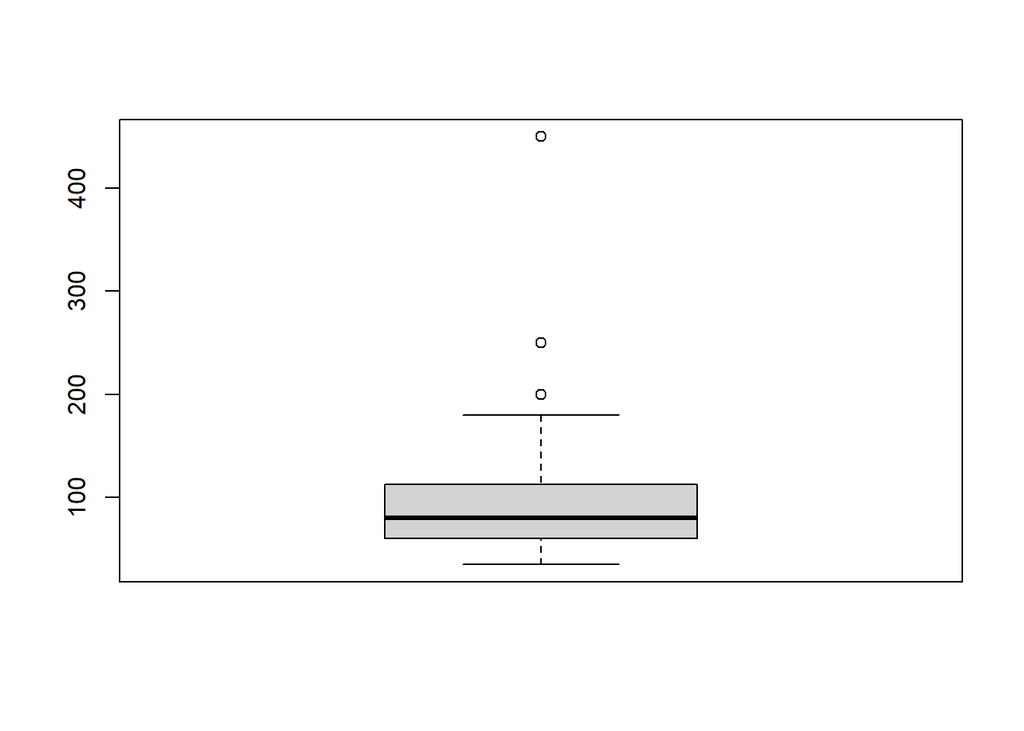

```r
#Grafica de bigotes, para identificar los datos atipicos
boxplot(DF$price)
```

Análisis:

#### De puntos

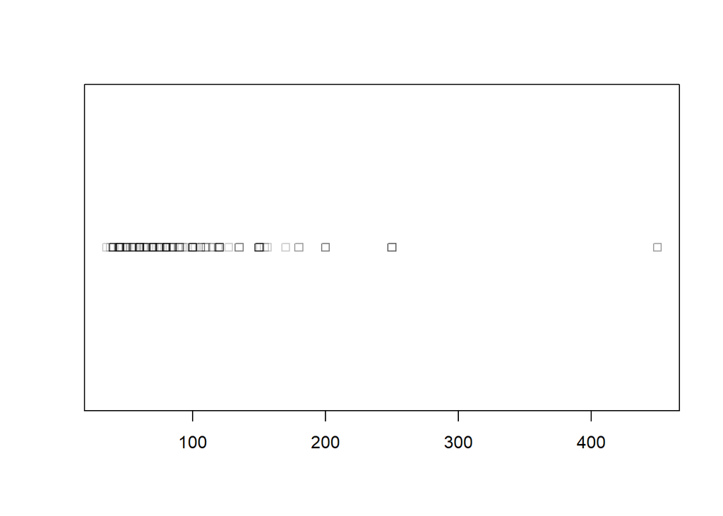

```r
#Grafica de puntos en linea recta, se usa para identficar  datos atipicos
stripchart(DF$price, col=rgb(0,0,0,0.2))
```

Se observa que los precios rondan más entre los 40 y 120.

####Histograma

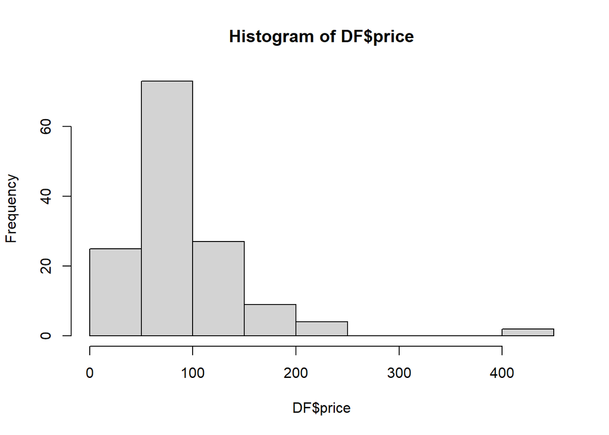

```r
#Histograma
hist(DF$price)
```

### Media

```r
mean(DF$price,na.rm=TRUE)
```

```
## [1] 96.04286
```

### Mediana

```r
median(DF$price,na.rm=TRUE)
```

```
## [1] 80
```

La media difiere un poco de la mediana.

### Moda

```r
table(DF$price)[table(DF$price)==max(table(DF$price))]
```

```
##
## 60 80
## 10 10
```

Existen 2 modas: 60 y 80 unidades.

### Cuantiles

```r
cuantiles <- quantile(DF$price, type=2,na.rm=TRUE)
cuantiles
```

```
##    0%   25%   50%   75%  100%
##  35.0  60.0  80.0 112.5 450.0
```

El el precio del 25% de los hospedajes es 60 o menos. Del 50%, es 80 o menos. Y del 100%, son 450 o menos.

### Rango

```r
rango <- max(DF$price,na.rm=TRUE) - min(DF$price,na.rm=TRUE)
rango
```

```
## [1] 415
```

En este caso los datos varían bastante. Sin embargo, para ser hospedajes es una variación razonable.

### Rango intercuartil

```r
IQR(DF$price,na.rm=TRUE)
```

```
## [1] 51.25
```

El 50% de los datos varía entre casi 51 unidades.

### Desviación estandar

```r
dv <- sd(DF$price,na.rm=TRUE)
dv
```

```
## [1] 63.14513
```

Se observa una dispersión moderada en los datos en general.

### Varianza

```r
varianza <- dv^2
varianza
```

```
## [1] 3987.308
```

### Coeficiente de variación

```r
cv <- function(x){
  return(sd(x, na.rm= TRUE)/mean(x, na.rm = TRUE))
}

cv(DF$price)
```

```
## [1] 0.6574683
```

## Minimum_nights

```r
table(DF$minimum_nights)
```

```
##
##   1   2   3   4   5   6   7  10  13  15  20  30  31  35  80  90  91 365
##  41  26  32  13   7   4   5   3   1   1   2  10   1   1   1   2   1  49
```

Es numérica, entonces podemos hallar sus descriptores numéricos.

### Descriptores gráficos

#### Boxplot

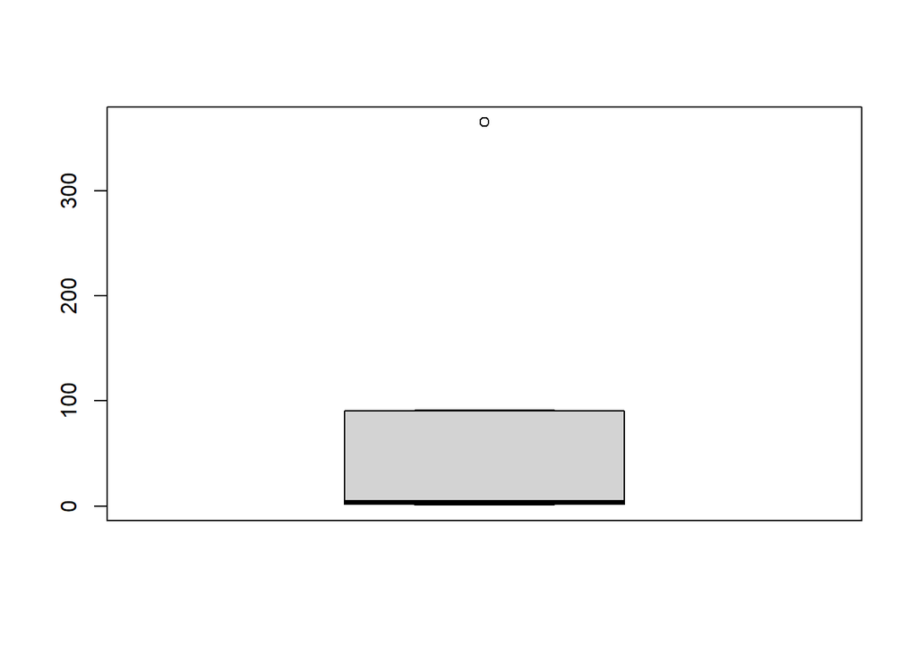

```r
#Grafica de bigotes, para identificar los datos atipicos
boxplot(DF$minimum_nights)
```

#### De puntos

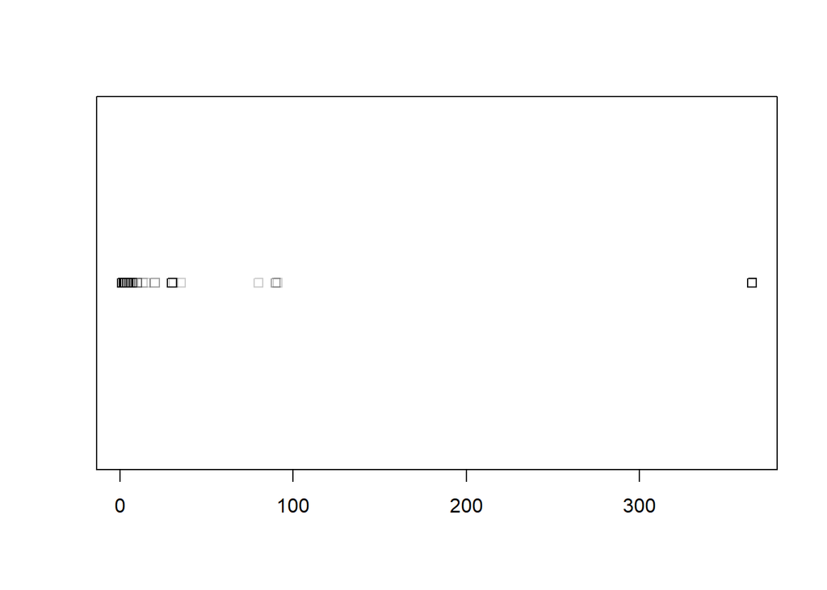

```r
#Grafica de puntos en linea recta, se usa para identficar  datos atipicos
stripchart(DF$minimum_nights,col=rgb(0,0,0,0.2))
```

Podemos observar que se concentra entre 0 y 50 noche aproximadamente. #### Histograma

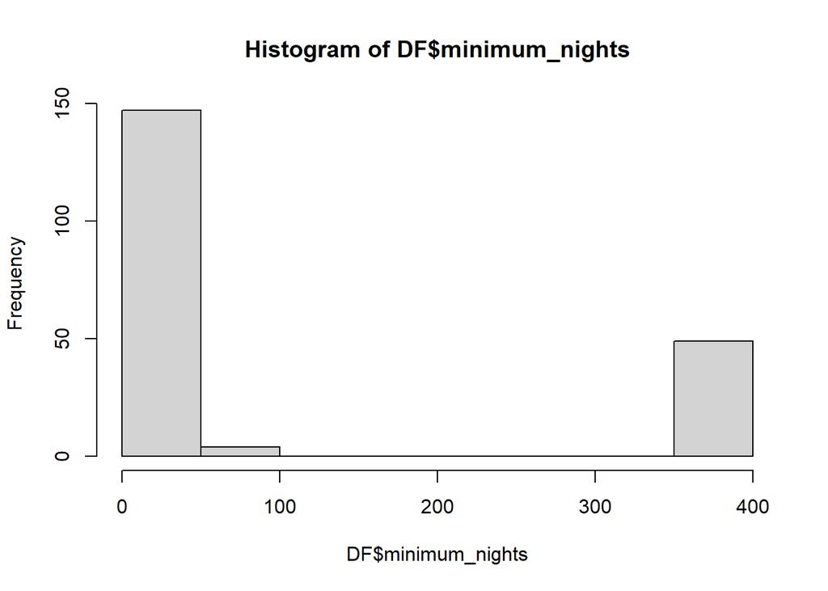

```r
#Histograma
hist(DF$minimum_nights)
```

Efectivamente el mínimo de noches son de 0 a 50 aproximadamente. ### Media

```r
mean(DF$minimum_nights,na.rm=TRUE)
```

```
## [1] 95.175
```

En promedio la cantidad mínima de noches es de 95, aunque esto se ve bastante afectada por los datos atípicos. ### Mediana

```r
median(DF$minimum_nights,na.rm=TRUE)
```

```
## [1] 4
```

Varia mucho de la media, podemos afirmar que los datos atípicos influyeron en esto. ### Moda

```r
table(DF$minimum_nights)[table(DF$minimum_nights)==max(table(DF$minimum_nights))]
```

```
## 365
##  49
```

### Cuantiles

```r
cuantiles <- quantile(DF$minimum_nights, type=2,na.rm=TRUE)
cuantiles
```

```
##    0%   25%   50%   75%  100%
##   1.0   2.0   4.0  90.5 365.0
```

El mínimo de noches del 25% de los hospedajes es 2 o menos. Del 50%, es 4 o menos. Y del 100%, son 365 o menos. ### Rango

```r
rango <- max(DF$minimum_nights,na.rm=TRUE) - min(DF$minimum_nights,na.rm=TRUE)
rango
```

```
## [1] 364
```

La diferencia entre el mínimo de noches y el máximo es de 364. ### Rango intercuartil

```r
IQR(DF$minimum_nights,na.rm=TRUE)
```

```
## [1] 88.25
```

El 50% de los datos varía entre casi 88 noches. ### Desviación estandar

```r
dv <- sd(DF$minimum_nights,na.rm=TRUE)
dv
```

```
## [1] 154.6781
```

Observamos que se varia bastante de la media.

### Varianza

```r
varianza <- dv^2
varianza
```

```
## [1] 23925.3
```

### Coeficiente de variación

```r
cv <- function(x){
  return(sd(x, na.rm= TRUE)/mean(x, na.rm = TRUE))
}

cv(DF$minimum_nights)
```

```
## [1] 1.625196
```

Hay una variación notable.

## Maximum_nights

```r
table(DF$maximum_nights)
```

```
##
##    6    7   10   14   15   21   25   26   28   29   30   31   32   60   70   85
##    2    3    5    2    7    2    1    1    1    1    5    2    1    3    2    1
##   90   99  120  180  183  300  305  365  999 1111 1124 1125
##    3    1    2    1    1    1    1   27    1    1    2  120
```

Es numérica, entonces podemos hallar sus descriptores numéricos.

### Descriptores gráficos

#### Boxplot

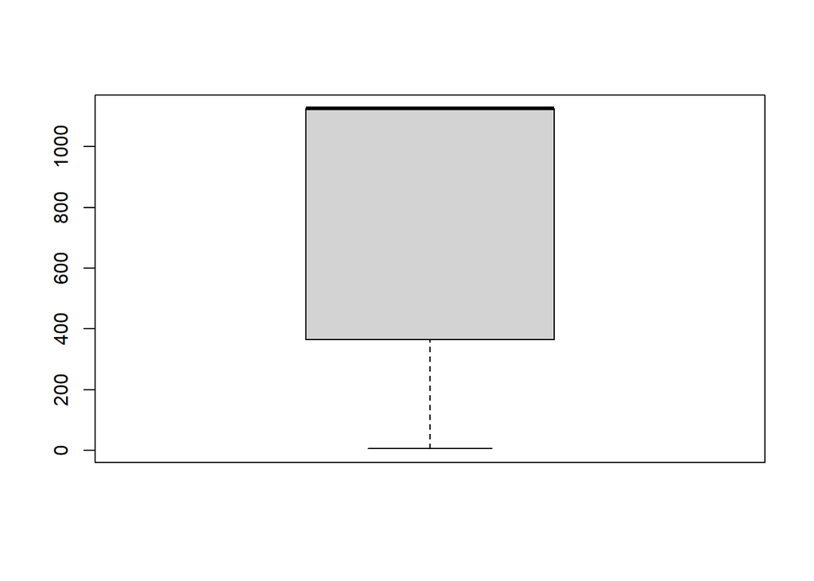

```r
#Grafica de bigotes, para identificar los datos atipicos
boxplot(DF$maximum_nights)
```

Interpretación: El 50% de los datos se encuentran entre 400 y más de 1000, lo que indica que los datos están bastante distribuidos.

#### De puntos

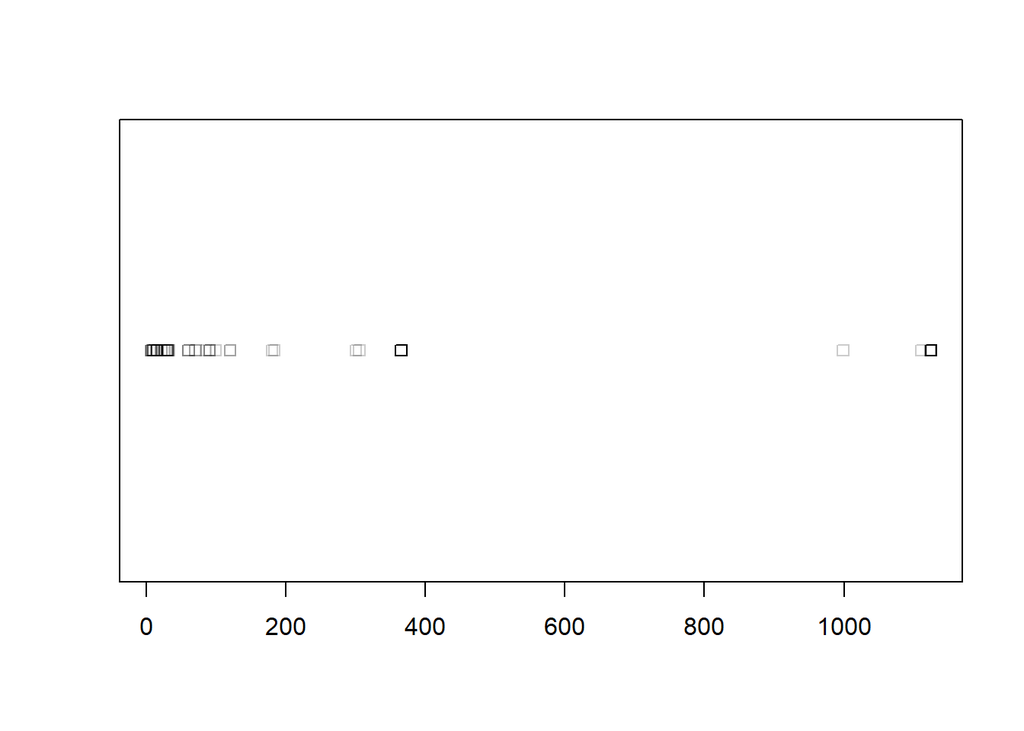

```r
#Grafica de puntos en linea recta, se usa para identficar  datos atipicos
stripchart(DF$maximum_nights,col=rgb(0,0,0,0.2))
```

#### Histograma

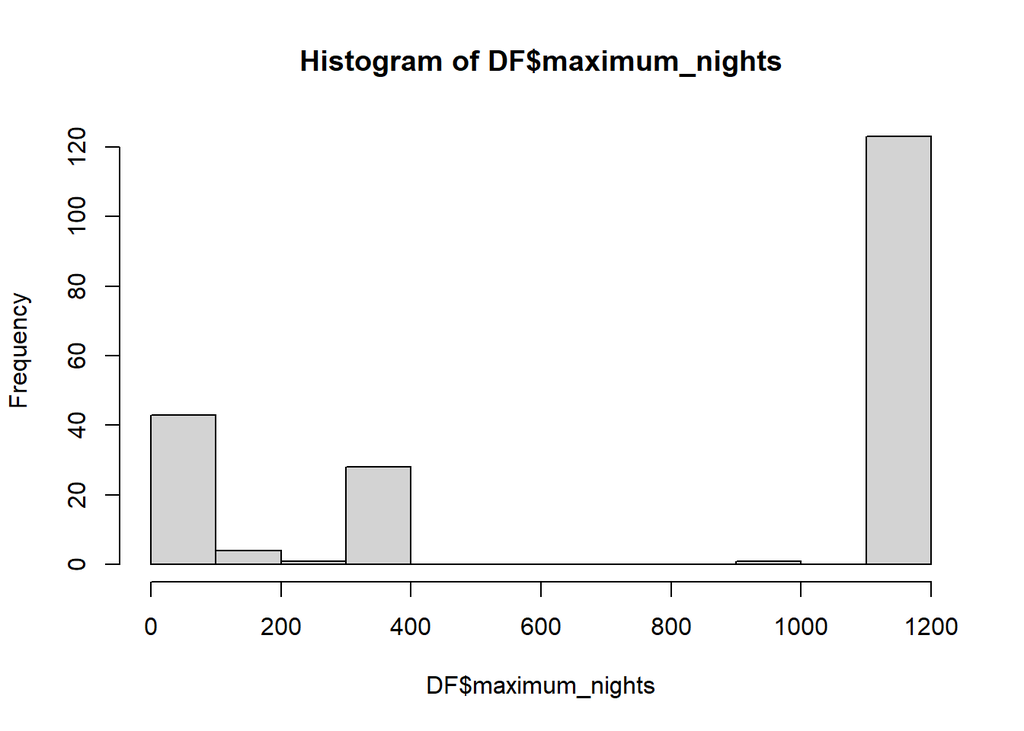

```r
#Histograma
hist(DF$maximum_nights)
```

La mayoría se encuentra entre 1100 y 1200 noches maximas. ### Media

```r
mean(DF$maximum_nights,na.rm=TRUE)
```

```
## [1] 759.025
```

En promedio la cantidad máxima de noche es de 759. ### Mediana

```r
median(DF$maximum_nights,na.rm=TRUE)
```

```
## [1] 1125
```

Observamos que la mediana varia bastante de la media, debido a los datos atípicos. ### Moda

```r
table(DF$maximum_nights)[table(DF$maximum_nights)==max(table(DF$maximum_nights))]
```

```
## 1125
##  120
```

La única moda es 1125.

### Cuantiles

```r
cuantiles <- quantile(DF$maximum_nights, type=2,na.rm=TRUE)
cuantiles
```

```
##   0%  25%  50%  75% 100%
##    6  365 1125 1125 1125
```

25 % es menor-igual a 365 noche máximas, el 50% menor-igual de 1125, el 75% menor o igual de 1125, y 100% menor-igual de 1125 ### Rango

```r
rango <- max(DF$maximum_nights,na.rm=TRUE) - min(DF$maximum_nights,na.rm=TRUE)
rango
```

```
## [1] 1119
```

La diferencia entre dato mínimo y máximo es de 1119. ### Rango intercuartil

```r
IQR(DF$maximum_nights,na.rm=TRUE)
```

```
## [1] 760
```

El 50% datos varia entre 760 noches máximas.  
### Desviación estandar

```r
dv <- sd(DF$maximum_nights,na.rm=TRUE)
dv
```

```
## [1] 477.4352
```

### Varianza

```r
varianza <- dv^2
varianza
```

```
## [1] 227944.4
```

### Coeficiente de variación

```r
cv <- function(x){
  return(sd(x, na.rm= TRUE)/mean(x, na.rm = TRUE))
}

cv(DF$maximum_nights)
```

```
## [1] 0.6290112
```

## has_availability

```r
DF %>% count(has_availability)
```

| has_availability | n |
| --- | --- |
| TRUE | 200 |

Es una variable categórica con un solo tipo de respuesta, entonces un gráfico no es necesario.

### Moda

```r
table(DF$has_availability)[table(DF$has_availability) == max(table(DF$has_availability))] # Moda
```

```
## TRUE
##  200
```

La moda es únicamente TRUE.

## number_of_reviews

```r
summary(DF$number_of_reviews)
```

```
##    Min. 1st Qu.  Median    Mean 3rd Qu.    Max.
##    0.00    1.00    5.50   22.48   28.00  239.00
```

### Descriptores de posicion

#### Media

```r
round(mean(DF$number_of_reviews),2)
```

```
## [1] 22.48
```

En promedio los hospedajes tienen 22 reseñas.

#### Mediana

```r
round(median(DF$number_of_reviews),2)
```

```
## [1] 5.5
```

Se observa que la mediana varia bastante de la media, debido a los datos atipicos. #### Moda

```r
table(DF$number_of_reviews)[table(DF$number_of_reviews)==max(table(DF$number_of_reviews))]
```

```
##  0
## 46
```

Observamos que la moda es 0. Quiere decir que hay muchos hospedajes sin reseñas.

#### Cuantiles

```r
quantile(DF$number_of_reviews)
```

```
##    0%   25%   50%   75%  100%
##   0.0   1.0   5.5  28.0 239.0
```

El 25% menor_igual de 1 reseña, el 50% menor-iguañ de 5.5 reseñas, el 75% menor-igual de 28% y el 100% menor-igual de 239 reseñas. #### Maximo y minimo

```r
max(DF$number_of_reviews)
```

```
## [1] 239
```

```r
min(DF$number_of_reviews)
```

```
## [1] 0
```

### Descriptores de dispersión

#### Rango

```r
max(DF$number_of_reviews, na.rm = TRUE) - min(DF$number_of_reviews, na.rm = TRUE)
```

```
## [1] 239
```

Indica la diferencia entre la cantidad de reseña mínima y máxima. #### Varianza

```r
var(DF$number_of_reviews)
```

```
## [1] 1493.899
```

#### Desviación Estandar

```r
sd(DF$number_of_reviews)
```

```
## [1] 38.65099
```

#### Rango intercuartil

```r
IQR(DF$number_of_reviews)
```

```
## [1] 27
```

El 50% de los datos varía entre 27 numero de reseñas. ### Gráficos

#### Histograma

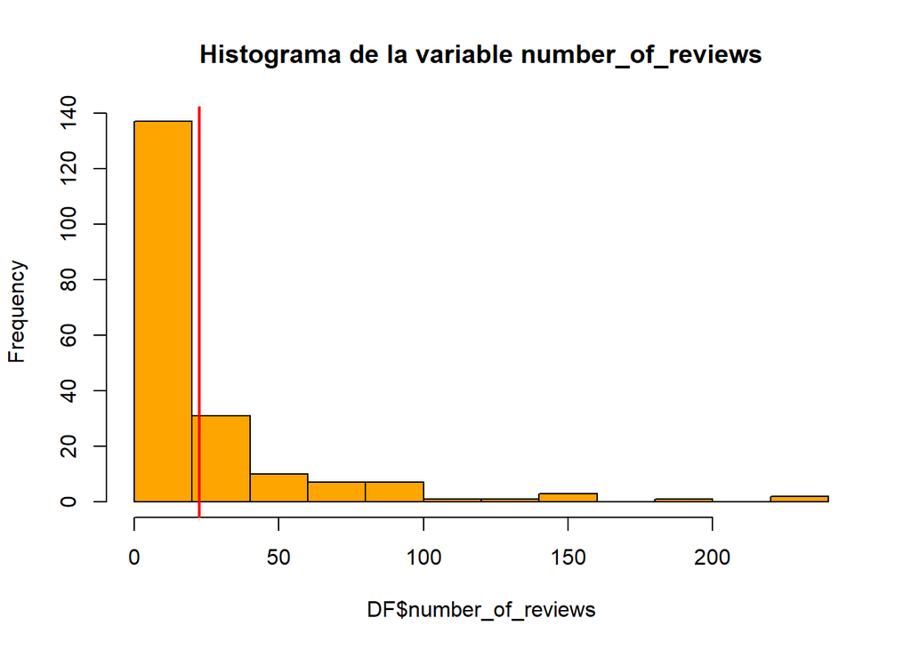

```r
hist(DF$number_of_reviews,breaks = 15,main = "Histograma de la variable number_of_reviews",col = "orange")
abline(v=mean(DF$number_of_reviews),col="red",lwd=2)
```

Observamos que hay más reseñas entre 0 y 23 aproximadamente. #### De puntos

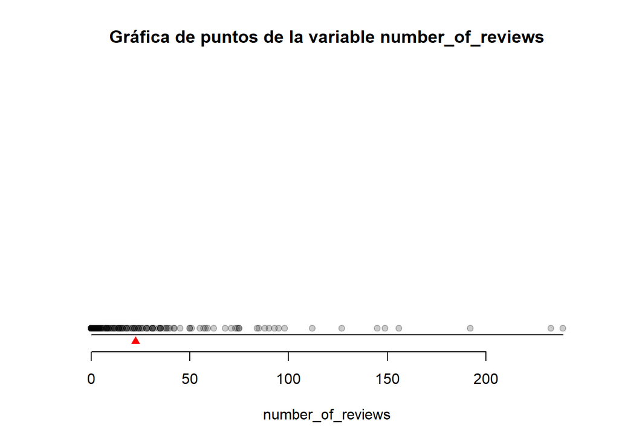

```r
#library(graphics)
y=0.025
d=0.025
stripchart(DF$number_of_reviews,method="overplot",pch=19,bty="n",frame.plot = FALSE,at=y+d,main="Gráfica de puntos de la variable number_of_reviews",ylim = c(0,1),xlab="number_of_reviews",col=rgb(0,0,0,0.2))
lines(c(min(DF$number_of_reviews),max(DF$number_of_reviews)),c(y,y),col="black")
points(c(mean(DF$number_of_reviews)),c(y-d),pch=17,col="red")
```

Se observa claramente que el número de reseñas se concentra entre 0 y 23 aproximadamente. #### Boxplot

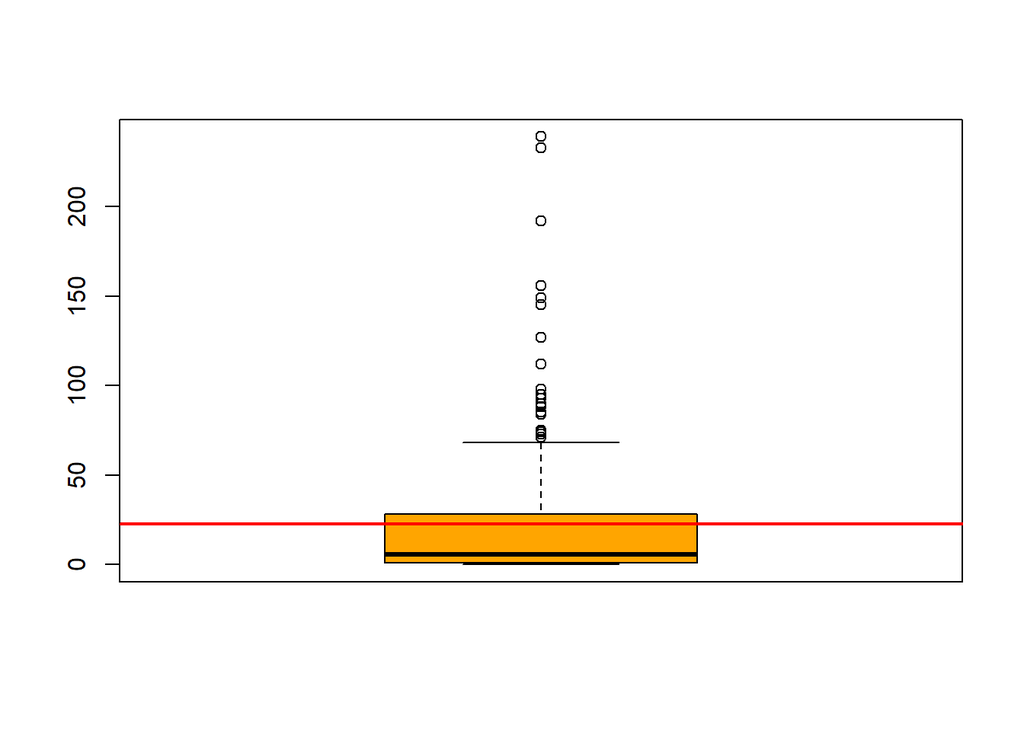

```r
boxplot(DF$number_of_reviews,col = "orange")
abline(h=mean(DF$number_of_reviews),col="red",lwd=2)
```

### Coeficiente de Variación

```r
cv <- function(x){
  return(sd(x, na.rm= TRUE)/mean(x, na.rm = TRUE))
}
```

```r
cv(DF$number_of_reviews)
```

```
## [1] 1.719733
```

## review_scores_value

```r
table(DF$review_scores_value)
```

```
##
##    3 3.25  3.5  3.6 3.75  3.8 3.92    4 4.05 4.17 4.25 4.26 4.28 4.29 4.33 4.37
##    1    2    1    1    1    1    1    6    1    2    1    2    1    1    3    1
## 4.38 4.39 4.42 4.43 4.44 4.46 4.47  4.5 4.52 4.53 4.54 4.56 4.57  4.6 4.62 4.63
##    1    1    1    3    1    1    1    8    2    2    2    1    1    1    2    1
## 4.64 4.67 4.68 4.69  4.7 4.71 4.72 4.73 4.75 4.76 4.77 4.78 4.79  4.8 4.81 4.82
##    2    6    2    2    1    4    3    2    3    2    4    4    1    5    4    2
## 4.83 4.84 4.85 4.86 4.87 4.88  4.9 4.91 4.93 4.94 4.96    5
##    1    1    1    3    2    5    1    1    1    1    2   29
```

Es numérica, se pueden hallar sus descriptores numéricos

### Descriptores gráficos

#### Boxplot

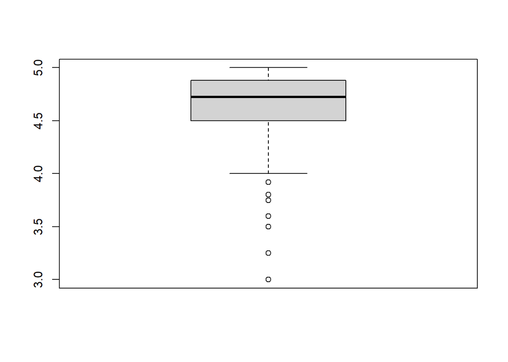

```r
#Grafica de bigotes, para identificar los datos atipicos
boxplot(DF$review_scores_value)
```

- El 50% de review_scores_value se encuentra entre 4.5 y 4.8 aproximadamente. -Existen muchos datos atípicos por debajo de 4.

#### De puntos

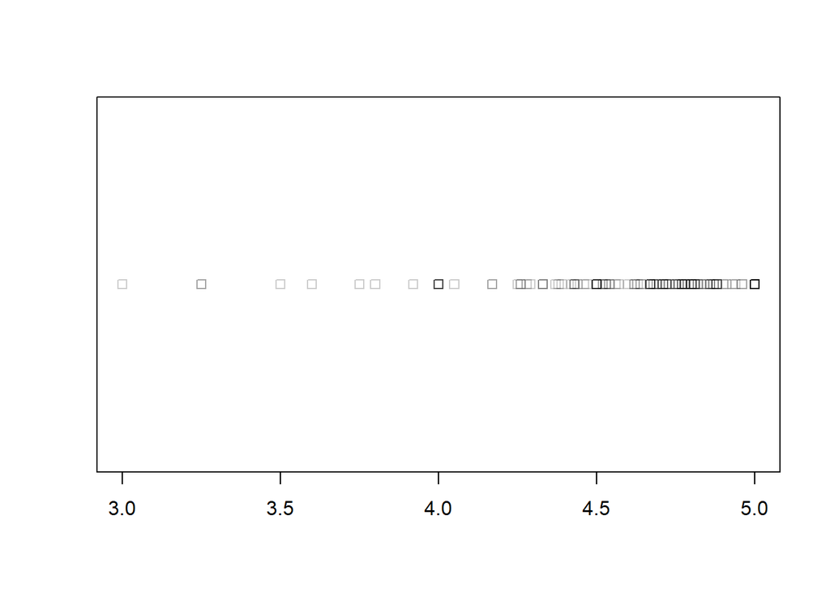

```r
#Grafica de puntos en linea recta, se usa para identficar  datos atipicos
stripchart(DF$review_scores_value,col=rgb(0,0,0,0.2))
```

#### Histograma

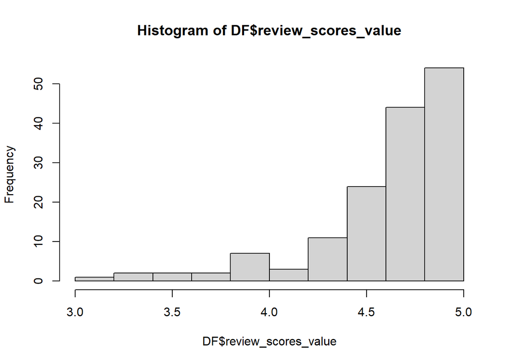

```r
#Histograma
hist(DF$review_scores_value)
```

```r
mean(DF$review_scores_value,na.rm=TRUE)
```

```
## [1] 4.6298
```

En promedio el review_scores_value es de 4.6298. ### Mediana

```r
median(DF$review_scores_value,na.rm=TRUE)
```

```
## [1] 4.725
```

La media no varia mucho de la mediana. ### Moda

```r
table(DF$review_scores_value)[table(DF$review_scores_value)==max(table(DF$review_scores_value))]
```

```
##  5
## 29
```

La única moda es 5.

### Cuantiles

```r
cuantiles <- quantile(DF$review_scores_value, type=2,na.rm=TRUE)
cuantiles
```

```
##    0%   25%   50%   75%  100%
## 3.000 4.500 4.725 4.880 5.000
```

El 25 % tiene menor_igual de 4.5, el 50% menor-igual de 4.725, el 75% menor-igual de 4.880 y el 100% menor-igual de 5. ### Rango

```r
rango <- max(DF$review_scores_value,na.rm=TRUE) - min(DF$review_scores_value,na.rm=TRUE)
rango
```

```
## [1] 2
```

La diferencia entre el dato mínimo y máximo es de 2. ### Rango intercuartil

```r
IQR(DF$review_scores_value,na.rm=TRUE)
```

```
## [1] 0.38
```

El 50% de los datos varía entre 0.38 números de review_scores_value. ### Desviación estandar

```r
dv <- sd(DF$review_scores_value,na.rm=TRUE)
dv
```

```
## [1] 0.379368
```

Se observa que la dispersión de la distribución de datos es pequeña. ### Varianza

```r
varianza <- dv^2
varianza
```

```
## [1] 0.1439201
```

La varianza es pequeña, podemos decir que es representativa. ### Coeficiente de variación

```r
cv <- function(x){
  return(sd(x, na.rm= TRUE)/mean(x, na.rm = TRUE))
}

cv(DF$review_scores_value)
```

```
## [1] 0.08194048
```

Por el valor del coeficiente de variación, podemos afirmar que la dispersión de la distribucion es pequeña. ## review_scores_cleanliness

```r
table(DF$review_scores_cleanliness)
```

```
##
## 2.42  2.5    3  3.4 3.75  3.8 3.83  3.9    4 4.02 4.06 4.09 4.15 4.22 4.23 4.25
##    1    1    1    1    2    1    1    1    7    1    1    1    1    1    1    2
## 4.31 4.32 4.36 4.38 4.41 4.43 4.44 4.46 4.48  4.5 4.51 4.55 4.56 4.57 4.58 4.62
##    1    1    1    2    1    2    1    2    1    7    1    2    1    3    2    2
## 4.65 4.67 4.68  4.7 4.71 4.72 4.74 4.75 4.76 4.78 4.79  4.8 4.82 4.83 4.84 4.85
##    1    8    1    1    1    1    2    1    1    3    3    5    2    3    1    6
## 4.86 4.87 4.88 4.89  4.9 4.91 4.92 4.93 4.94 4.95 4.98    5
##    1    2    4    2    3    7    1    2    1    1    1   31
```

Es numérica, se pueden hallar sus descriptores numéricos.

### Descriptores gráficos

#### Bopxplot

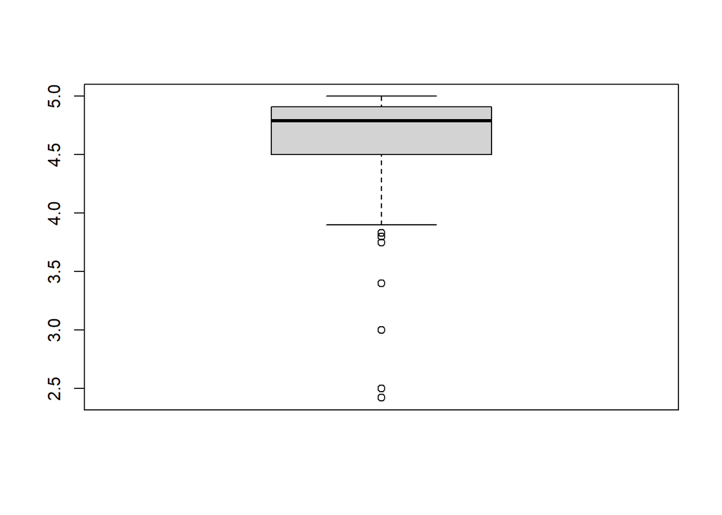

```r
#Grafica de bigotes, para identificar los datos atipicos
boxplot(DF$review_scores_cleanliness)
```

#### De puntos

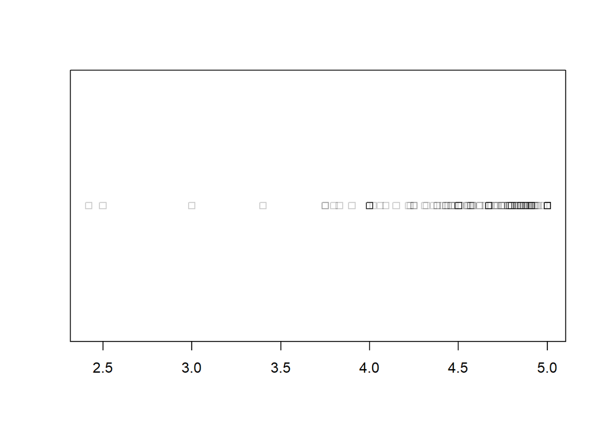

```r
#Grafica de puntos en linea recta, se usa para identficar  datos atipicos
stripchart(DF$review_scores_cleanliness,col=rgb(0,0,0,0.2))
```

Observamos que los datos se concentran entre 4.5 y 5 aproximadamente.

#### Histograma

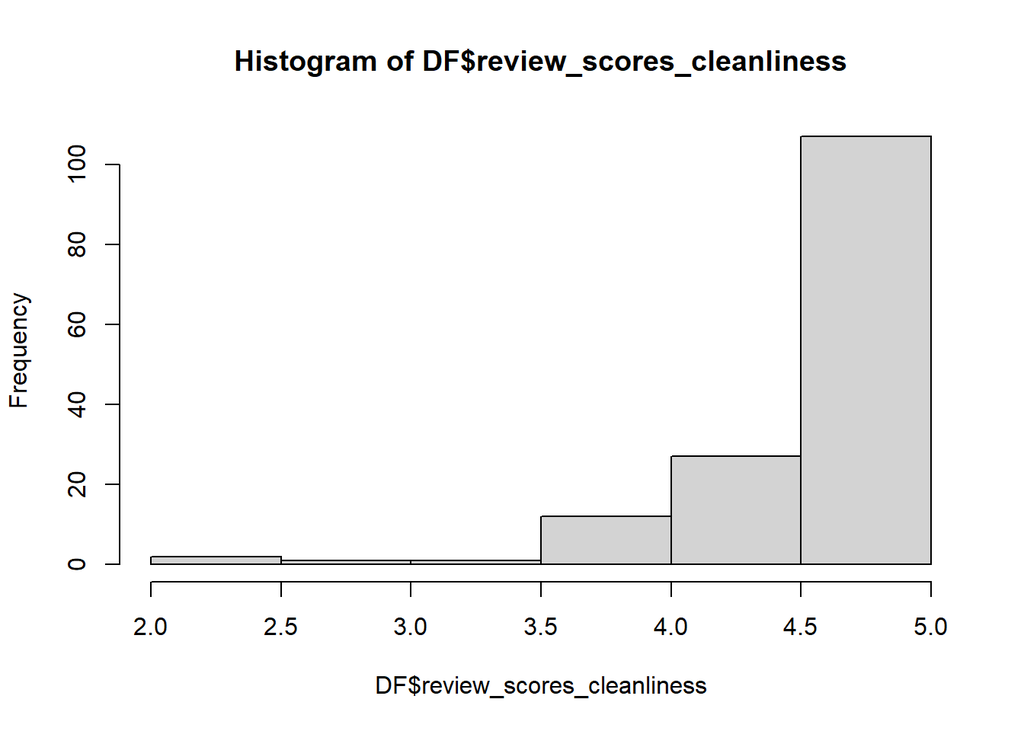

```r
#Histograma
hist(DF$review_scores_cleanliness)
```

-Se observa que hay mas datos entre 4.5 y 5. ### Media

```r
mean(DF$review_scores_cleanliness,na.rm=TRUE)
```

```
## [1] 4.6298
```

-El promedio de review_scores_cleanliness de los hospedajes. ### Mediana

```r
median(DF$review_scores_cleanliness,na.rm=TRUE)
```

```
## [1] 4.79
```

```r
table(DF$review_scores_cleanliness)[table(DF$review_scores_cleanliness)==max(table(DF$review_scores_cleanliness))]
```

```
##  5
## 31
```

La única moda es 5.

### Cuantiles

```r
cuantiles <- quantile(DF$review_scores_cleanliness, type=2,na.rm=TRUE)
cuantiles
```

```
##   0%  25%  50%  75% 100%
## 2.42 4.50 4.79 4.91 5.00
```

El 25% de review_scores_cleanliness son menor-igual a 4.5, el 50% menor-igual a 4.79, el 75% menor-igual a 4.91 y el 100% menor-igual a 5.

### Rango

```r
rango <- max(DF$review_scores_cleanliness,na.rm=TRUE) - min(DF$review_scores_cleanliness,na.rm=TRUE)
rango
```

```
## [1] 2.58
```

La diferencia entre el dato mínimo y máximo es de 2.58.

### Rango intercuartil

```r
IQR(DF$review_scores_cleanliness,na.rm=TRUE)
```

```
## [1] 0.41
```

El 50% de los datos varían entre 0.41 review_scores_cleanliness. ### Desviación estandar

```r
dv <- sd(DF$review_scores_cleanliness,na.rm=TRUE)
dv
```

```
## [1] 0.4447991
```

Se observa que la dispersión entre los datos es bastante pequeña. ### Varianza

```r
varianza <- dv^2
varianza
```

```
## [1] 0.1978463
```

Los datos no estan tan dispersos respecto a la media. ### Coeficiente de variación

```r
cv <- function(x){
  return(sd(x, na.rm= TRUE)/mean(x, na.rm = TRUE))
}

cv(DF$review_scores_cleanliness)
```

```
## [1] 0.09607308
```

El grado de variabilidad es pequeña. ## review_scores_checkin